# NBA Leading Scorers Analysis

Aidan Judge

## Introduction

My subject of interest for this project is NBA basketball players: specifically the top 100 scorers of the 2017-2018 season. I compiled data including offensive and defensive statistics as well as personal data on players including height, weight, where they went to college, as well as how many years, if any, they spent in college. The first hypothesis I made about the large set of data that I had compiled was that there must be some correlation between a player’s net rating and the number of points they score. A player’s net rating is a statistic that rates the player’s overall effectiveness by averaging their team’s net score differential while that specific player is on and off the floor. I hypothesized that there would be a positive correlation, but doubted this would be a model with a high R^2 given that there are some great, high-scoring players even on the worst (think low net rating) teams. My second hypothesis was that players chosen in the first round of the NBA draft would average more than players chosen in the second round or later. My third hypothesis was that those players chosen in the first round would also average a significantly higher net rating as they usually come from better, more competitive college basketball programs.

## Methods

I largely collected my dataset using personal player information and statistics from nba.com, but I had some blanks to fill in for personal information using the ncaa’s college basketball website. The two numerical values that I decided on using in the analysis were points per game (total points divided by games played) and net rating which is a player efficiency rating of team points scored minus team points allowed for every 100 total points that the player is on the floor. The first model uses a basic linear model with a 95% confidence interval to regress points per game as a function of net rating. The second and third models looked at estimates for the average points per game and player net rating, respectively, both using players drafted in the first round as the baseline for the group. The hypothesis was that players drafted in the first round would have have higher averages for scoring and net rating so the baseline group here was made to be the first round and thus we expect a negative estimate for the second round difference variable.

## Results

```
##
## Call:
## lm_basic(formula = pts ~ 1 + netrtg, data = nba)
##
## Residuals:
##     Min      1Q  Median      3Q     Max
## -6.4062 -2.9931 -0.7271  2.7779 10.1334
##
## Coefficients:
##             Estimate   2.5 % 97.5 %
## (Intercept)  17.7979 17.0097 18.586
## netrtg        0.2669  0.1358  0.398
##
## Residual standard error: 3.914 on 98 degrees of freedom
## Multiple R-squared:  0.1429, Adjusted R-squared:  0.1341
## F-statistic: 16.34 on 1 and 98 DF,  p-value: 0.0001056
```

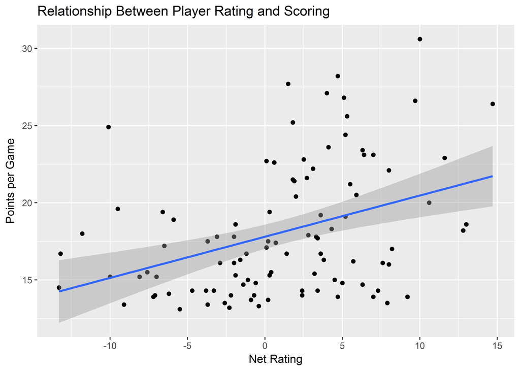

For Model 1, I regressed points per game on players’ net ratings and produced a basic scatter plot with a trend line showing the positive relationship.

```
##
## Call:
## lm_basic(formula = pts ~ 1 + draft_round, data = nba)
##
## Residuals:
##    Min     1Q Median     3Q    Max
## -5.245 -3.195 -1.208  2.905 12.255
##
## Coefficients:
##                                  Estimate  2.5 % 97.5 %
## (Intercept)                        18.345 17.453 19.238
## draft_roundSecond Round or Later   -1.974 -4.359  0.412
##
## Residual standard error: 4.171 on 98 degrees of freedom
## Multiple R-squared:  0.02678,    Adjusted R-squared:  0.01685
## F-statistic: 2.696 on 1 and 98 DF,  p-value: 0.1038
```

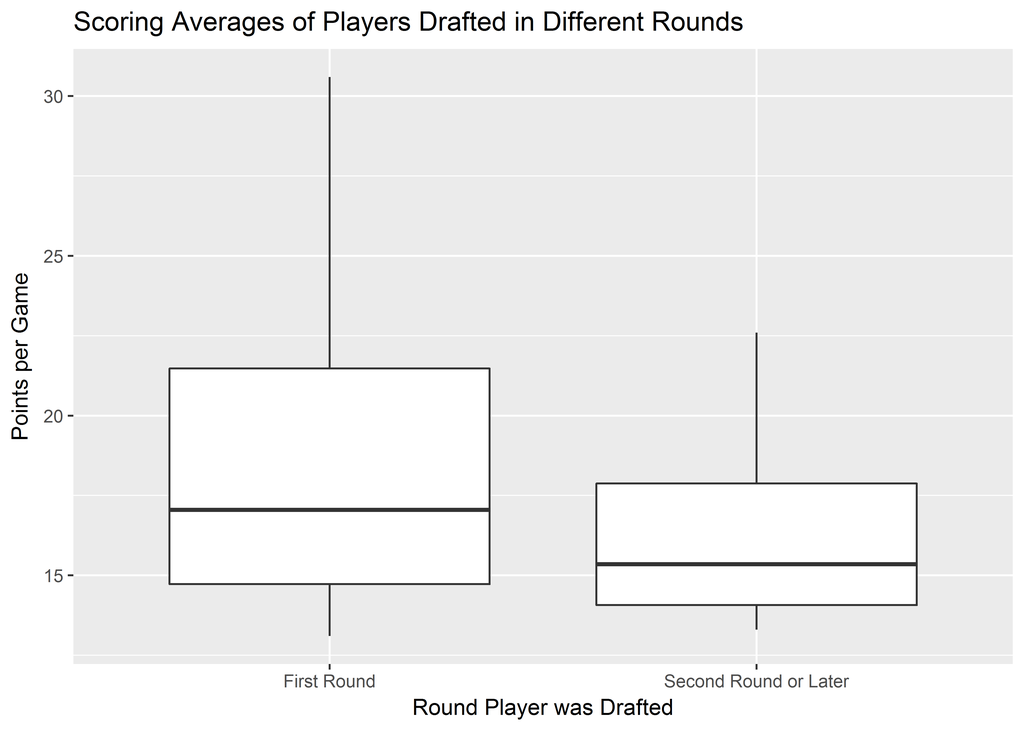

For Model 2, I compared the means of points per game for players selected in the first round of the NBA draft versus those selected in the second round or not selected at all and later signed in free agency. I graphically displayed these different means using a boxplot to show that while the means were generally not too far apart, players drafted in the first round appear to have more positive skewness.

```
##
## Call:
## lm_basic(formula = netrtg ~ 1 + draft_round, data = nba)
##
## Residuals:
##     Min      1Q  Median      3Q     Max
## -14.730  -3.805   1.020   3.885  13.270
##
## Coefficients:
##                                  Estimate  2.5 % 97.5 %
## (Intercept)                         1.430  0.168  2.692
## draft_roundSecond Round or Later   -2.959 -6.332  0.415
##
## Residual standard error: 5.898 on 98 degrees of freedom
## Multiple R-squared:  0.02999,    Adjusted R-squared:  0.02009
## F-statistic:  3.03 on 1 and 98 DF,  p-value: 0.08489
```

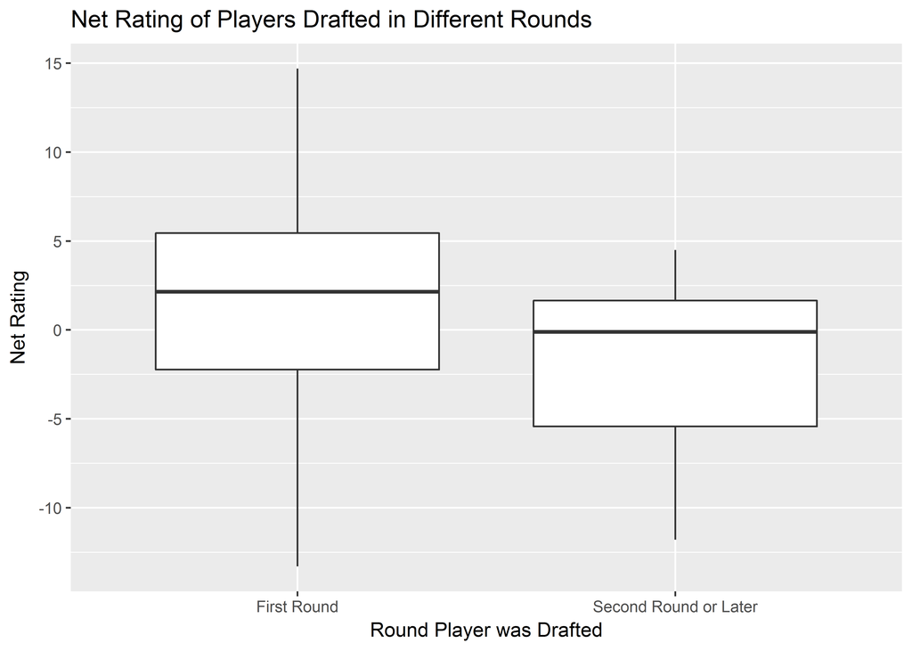

For Model 3, I compared the means of net ratings for players selected in the first round of the NBA draft versus those selected in the second round or not selected at all and later signed in free agency. I once again graphically displayed these different means using a boxplot to show that net rating for players drafted in the first round appear to have more positive skewness than the group drafted in the second round or later.

## Conclusions

For Model 1, there is a positive correlation as I hypothesized and it is statistically significant because 0 falls outside of the 95% confidence interval (.1358, .398) for the netrating variable. This means that there is a significant relationship between a player’s net rating and points per game such that for every additional point of net rating, a player is estimated to average .2669 more points per game. Since we are looking at the top 100 scorers in the NBA, it is no surprise that the estimate for players with a net rating of 0 is still 17.7979 points per game, and it is important to understand that since net rating can be a negative integer, this estimate also indicates that a player with a negative net rating is estimated with the same significance to average .2669 fewer points per game for every decrease in net rating of one point. The fact that there was a statistically significant relationship, but also a low R^2 for the model because of the innumerable high-scoring players on teams with bad net ratings followed my expectations. For Model 2, I was somewhat surprised that the average points per game for players drafted in the second round or later was not found to be statistically significantly lower than those drafted in the first round. The fact that the basica estimate for players drafted in the second round was lower and that the positive skewness was greater for first round players fell in line with expectations. For Model 3, the graphical output fell in line with my expectations that players drafted in the first round would have higher basic estimates for net rating with more positive skewness than those players drafted in the second round or later. What was interesting in Model 3 was how close the difference came to being statistically significant. In fact, the lower average net rating for players drafted in the second round or later would have been statistically significant on a 90% confidence interval (-5.7815, -.136), but did not quite cut it on the 95% interval (-6.332, .415).

## References

https://stats.nba.com/leaders/ https://www.ncaa.com/sports/basketball-men/d1